# Chapter 5

## Dimensionality reduction techniques

In this chapter, we have looked at dimensionality reduction using PCA and MCA.

#### Dimensionality reduction using PCA

- Loading the human data We first load the human data containing Human development and gender inequality data for each country (original data obtained from : http://hdr.undp.org/en/content/human-development-index-hdi). The data combines several indicator variables of human development and gender inequality from 155 countries in the world. This data contains 155 observations (countries) and 8 variables (indicators) for each observation.

```r
human <- read.table("data/human.txt",header=T, sep="\t")
str(human)
```

```
## 'data.frame':    155 obs. of  8 variables:
##  $ SecondaryEducFtoM     : num  1.007 0.997 0.983 0.989 0.969 ...
##  $ LFPRFtoM              : num  0.891 0.819 0.825 0.884 0.829 ...
##  $ ExpEduInYears         : num  17.5 20.2 15.8 18.7 17.9 16.5 18.6 16.5 15.9 19.2 ...
##  $ LifeExpectancy        : num  81.6 82.4 83 80.2 81.6 80.9 80.9 79.1 82 81.8 ...
##  $ GNIperCapita          : int  64992 42261 56431 44025 45435 43919 39568 52947 42155 32689 ...
##  $ MaternalMortalityRatio: int  4 6 6 5 6 7 9 28 11 8 ...
##  $ AdolescentBirthRate   : num  7.8 12.1 1.9 5.1 6.2 3.8 8.2 31 14.5 25.3 ...
##  $ percentInParliament   : num  39.6 30.5 28.5 38 36.9 36.9 19.9 19.4 28.2 31.4 ...
```

- Overview of the human data

```r
summary(human)
```

```
##  SecondaryEducFtoM    LFPRFtoM      ExpEduInYears   LifeExpectancy
##  Min.   :0.1717    Min.   :0.1857   Min.   : 5.40   Min.   :49.00
##  1st Qu.:0.7264    1st Qu.:0.5984   1st Qu.:11.25   1st Qu.:66.30
##  Median :0.9375    Median :0.7535   Median :13.50   Median :74.20
##  Mean   :0.8529    Mean   :0.7074   Mean   :13.18   Mean   :71.65
##  3rd Qu.:0.9968    3rd Qu.:0.8535   3rd Qu.:15.20   3rd Qu.:77.25
##  Max.   :1.4967    Max.   :1.0380   Max.   :20.20   Max.   :83.50
##   GNIperCapita    MaternalMortalityRatio AdolescentBirthRate
##  Min.   :   581   Min.   :   1.0         Min.   :  0.60
##  1st Qu.:  4198   1st Qu.:  11.5         1st Qu.: 12.65
##  Median : 12040   Median :  49.0         Median : 33.60
##  Mean   : 17628   Mean   : 149.1         Mean   : 47.16
##  3rd Qu.: 24512   3rd Qu.: 190.0         3rd Qu.: 71.95
##  Max.   :123124   Max.   :1100.0         Max.   :204.80
##  percentInParliament
##  Min.   : 0.00
##  1st Qu.:12.40
##  Median :19.30
##  Mean   :20.91
##  3rd Qu.:27.95
##  Max.   :57.50
```

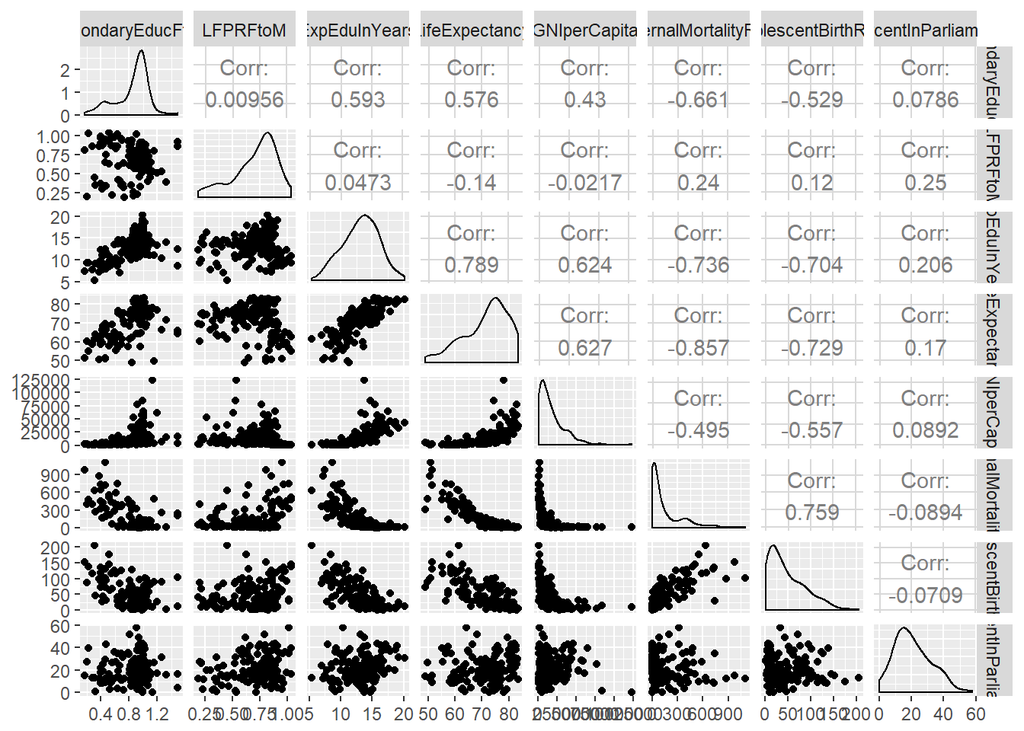

```r
library(GGally)

ggpairs(human)
```

The mean and range of each variables across the 155 countries can be seen using summary(human). The mean GNI per capita is 17628. Mean percentage of women in parlament is approx. 21%, which is much lower than the expected 50%. As can be seen from the correlations indicated above, there is a strong negative correlation between maternal mortality rate and life expectancy, and the strongest positive correlation is observed between expected education in years and life expectancy.

- perfrom PCA

We first perform PCA on the not standardized human data. As can be seen in the summary output, the first principal component PC1 captures more than 99% of the variability in the data. PC1 and PC2 combined capture 100% of the variability.

```r
pcaNS_human <- prcomp(human)
summary(pcaNS_human)
```

```
## Importance of components:
##                              PC1      PC2   PC3   PC4   PC5   PC6    PC7
## Standard deviation     1.854e+04 185.5219 25.19 11.45 3.766 1.566 0.1912
## Proportion of Variance 9.999e-01   0.0001  0.00  0.00 0.000 0.000 0.0000
## Cumulative Proportion  9.999e-01   1.0000  1.00  1.00 1.000 1.000 1.0000
##                           PC8
## Standard deviation     0.1591
## Proportion of Variance 0.0000
## Cumulative Proportion  1.0000
```

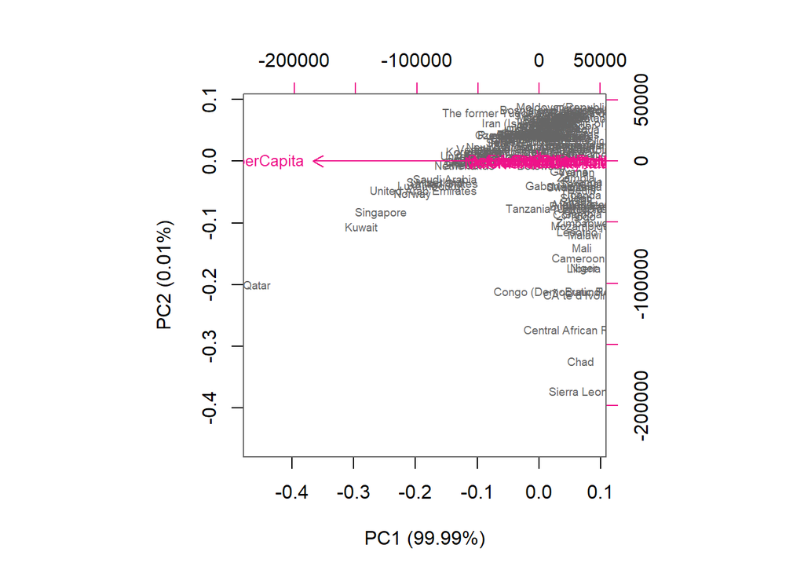

HumanPCA.1: PCA using non-standardized human data clusters countries mostly by PC1 which captures variation mostly from GNI per capita

```r
pca_pr <- round(100*summary(pcaNS_human)$importance[2, ], digits = 5)
pc_lab <- paste0(names(pca_pr), " (", pca_pr, "%)")

biplot(pcaNS_human, choices = 1:2,cex = c(0.6, 0.8),col = c("grey40", "deeppink2"),xlab = pc_lab[1], ylab = pc_lab[2])
```

As can be seen from the biplot of the pca above, the GNI per capita variable has a strong influence on PC1. It’s very possible that most of the variation is coming from this variable because of scaling differences between variables, with GNI per capita having high variation and range and thus affecting the PCA and biasing the result.

Next we perform PCA on the standardized human data set.

```r
human_std <- scale(human)
summary(human_std)
```

```
##  SecondaryEducFtoM    LFPRFtoM       ExpEduInYears     LifeExpectancy
##  Min.   :-2.8189   Min.   :-2.6247   Min.   :-2.7378   Min.   :-2.7188
##  1st Qu.:-0.5233   1st Qu.:-0.5484   1st Qu.:-0.6782   1st Qu.:-0.6425
##  Median : 0.3503   Median : 0.2316   Median : 0.1140   Median : 0.3056
##  Mean   : 0.0000   Mean   : 0.0000   Mean   : 0.0000   Mean   : 0.0000
##  3rd Qu.: 0.5958   3rd Qu.: 0.7350   3rd Qu.: 0.7126   3rd Qu.: 0.6717
##  Max.   : 2.6646   Max.   : 1.6632   Max.   : 2.4730   Max.   : 1.4218
##   GNIperCapita     MaternalMortalityRatio AdolescentBirthRate
##  Min.   :-0.9193   Min.   :-0.6992        Min.   :-1.1325
##  1st Qu.:-0.7243   1st Qu.:-0.6496        1st Qu.:-0.8394
##  Median :-0.3013   Median :-0.4726        Median :-0.3298
##  Mean   : 0.0000   Mean   : 0.0000        Mean   : 0.0000
##  3rd Qu.: 0.3712   3rd Qu.: 0.1932        3rd Qu.: 0.6030
##  Max.   : 5.6890   Max.   : 4.4899        Max.   : 3.8344
##  percentInParliament
##  Min.   :-1.8203
##  1st Qu.:-0.7409
##  Median :-0.1403
##  Mean   : 0.0000
##  3rd Qu.: 0.6127
##  Max.   : 3.1850
```

```r
pca_human <- prcomp(human_std)
summary(pca_human)
```

```
## Importance of components:
##                           PC1    PC2     PC3     PC4     PC5     PC6
## Standard deviation     2.0708 1.1397 0.87505 0.77886 0.66196 0.53631
## Proportion of Variance 0.5361 0.1624 0.09571 0.07583 0.05477 0.03595
## Cumulative Proportion  0.5361 0.6984 0.79413 0.86996 0.92473 0.96069
##                            PC7     PC8
## Standard deviation     0.45900 0.32224
## Proportion of Variance 0.02634 0.01298
## Cumulative Proportion  0.98702 1.00000
```

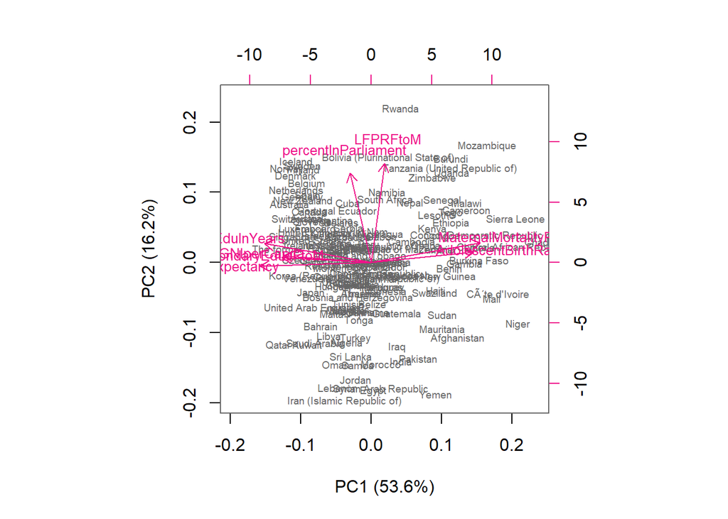

HumanPCA.2: PCA using standardized human data utilizes most variables and captures the real variation in the data instead of bias coming form few variables.In the biplot, countries with similar human development and gender inequality performance cluster together.

```r
pca_pr <- round(100*summary(pca_human)$importance[2, ], digits = 1)
pc_lab <- paste0(names(pca_pr), " (", pca_pr, "%)")

biplot(pca_human, choices = 1:2,cex = c(0.6, 0.8),col = c("grey40", "deeppink2"),xlab = pc_lab[1], ylab = pc_lab[2])
```

After performing PCA with the standardized human data (see above), PC1 captures 53.6% and PC2 captures 16.24% of the variablity in the data. The variablity captured by other principal components can be seen from the summary output above. PC1 and PC2 together capture 69.8% of the variability in the data. A biplot using PC1 and PC2 is also shown, with arrow direction indicating the variables that are contributing to the components. The PCA result obtained form the standardized human data is the proper way to do the analysis since we standardized all variables to the same scale, which allows PCA to work with the real variability in the data. When using data that is not standardized to the same scale, variables that have high range due to simply their measurement scale, will dominate the PCA resulting in wrong interpretation.

- Interpretation of PC1 and PC2 on standardized human data A number of insight can be gathered from HumanPCA.2. Expected years of education, life expectancy, GNI per capita, maternal mortality rate, adolescent birth rate are variables that contribute to PC1.countries with high expected years of education, life expectancy and GNI per capita cluster together. We can see counties with the opposite trend clustering together on the right hand of the plot. We could see that variables of female to male labor market ratio, and percent of females in parlament contribute to PC2, with those countries having higher female participation clustering in the top while those doing poorly in this regard clustering at the bottom. For example, Counties at the bottom-left could have good GNI,life expectancy etc but perform poorly in gender equality.
- Multiple Correspondence Analysis(MCA) on tea data

We first load the tea dataset from the FactoMineR package. The tea data has 300 observations with 36 variables. We select some variables (as was done in the datacamp exercise), and visualize them using a barplot. We then perform MCA on the tea data with the selected variables.

```r
library(FactoMineR);
library(dplyr);
library(tidyr);
library(ggplot2);

data("tea")

dim(tea)
```

```
## [1] 300  36
```

```r
str(tea)
```

```
## 'data.frame':    300 obs. of  36 variables:
##  $ breakfast       : Factor w/ 2 levels "breakfast","Not.breakfast": 1 1 2 2 1 2 1 2 1 1 ...
##  $ tea.time        : Factor w/ 2 levels "Not.tea time",..: 1 1 2 1 1 1 2 2 2 1 ...
##  $ evening         : Factor w/ 2 levels "evening","Not.evening": 2 2 1 2 1 2 2 1 2 1 ...
##  $ lunch           : Factor w/ 2 levels "lunch","Not.lunch": 2 2 2 2 2 2 2 2 2 2 ...
##  $ dinner          : Factor w/ 2 levels "dinner","Not.dinner": 2 2 1 1 2 1 2 2 2 2 ...
##  $ always          : Factor w/ 2 levels "always","Not.always": 2 2 2 2 1 2 2 2 2 2 ...
##  $ home            : Factor w/ 2 levels "home","Not.home": 1 1 1 1 1 1 1 1 1 1 ...
##  $ work            : Factor w/ 2 levels "Not.work","work": 1 1 2 1 1 1 1 1 1 1 ...
##  $ tearoom         : Factor w/ 2 levels "Not.tearoom",..: 1 1 1 1 1 1 1 1 1 2 ...
##  $ friends         : Factor w/ 2 levels "friends","Not.friends": 2 2 1 2 2 2 1 2 2 2 ...
##  $ resto           : Factor w/ 2 levels "Not.resto","resto": 1 1 2 1 1 1 1 1 1 1 ...
##  $ pub             : Factor w/ 2 levels "Not.pub","pub": 1 1 1 1 1 1 1 1 1 1 ...
##  $ Tea             : Factor w/ 3 levels "black","Earl Grey",..: 1 1 2 2 2 2 2 1 2 1 ...
##  $ How             : Factor w/ 4 levels "alone","lemon",..: 1 3 1 1 1 1 1 3 3 1 ...
```

[output cut: 22 more lines]

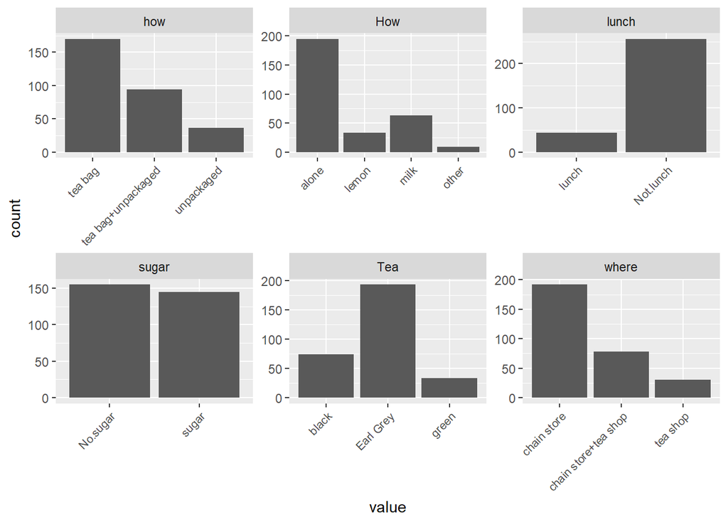

```r
# visualize the dataset using selected variables.
# column names to keep in the dataset
keep_columns <- c("Tea", "How", "how", "sugar", "where", "lunch")

# select the 'keep_columns' to create a new dataset
tea_time <- dplyr::select(tea, one_of(keep_columns))

gather(tea_time) %>% ggplot(aes(value)) + facet_wrap("key", scales = "free") + geom_bar() + theme(axis.text.x = element_text(angle = 45, hjust = 1, size = 8))
```

```r
# multiple correspondence analysis
mca <- MCA(tea_time, graph = FALSE)
summary(mca)
```

```
##
## Call:
## MCA(X = tea_time, graph = FALSE)
##
##
## Eigenvalues
##                        Dim.1   Dim.2   Dim.3   Dim.4   Dim.5   Dim.6
## Variance               0.279   0.261   0.219   0.189   0.177   0.156
## % of var.             15.238  14.232  11.964  10.333   9.667   8.519
## Cumulative % of var.  15.238  29.471  41.435  51.768  61.434  69.953
##                        Dim.7   Dim.8   Dim.9  Dim.10  Dim.11
## Variance               0.144   0.141   0.117   0.087   0.062
## % of var.              7.841   7.705   6.392   4.724   3.385
## Cumulative % of var.  77.794  85.500  91.891  96.615 100.000
##
## Individuals (the 10 first)
##                       Dim.1    ctr   cos2    Dim.2    ctr   cos2    Dim.3
## 1                  | -0.298  0.106  0.086 | -0.328  0.137  0.105 | -0.327
## 2                  | -0.237  0.067  0.036 | -0.136  0.024  0.012 | -0.695
## 3                  | -0.369  0.162  0.231 | -0.300  0.115  0.153 | -0.202
## 4                  | -0.530  0.335  0.460 | -0.318  0.129  0.166 |  0.211
## 5                  | -0.369  0.162  0.231 | -0.300  0.115  0.153 | -0.202
## 6                  | -0.369  0.162  0.231 | -0.300  0.115  0.153 | -0.202
## 7                  | -0.369  0.162  0.231 | -0.300  0.115  0.153 | -0.202
## 8                  | -0.237  0.067  0.036 | -0.136  0.024  0.012 | -0.695
## 9                  |  0.143  0.024  0.012 |  0.871  0.969  0.435 | -0.067
## 10                 |  0.476  0.271  0.140 |  0.687  0.604  0.291 | -0.650
##                       ctr   cos2
## 1                   0.163  0.104 |
## 2                   0.735  0.314 |
## 3                   0.062  0.069 |
## 4                   0.068  0.073 |
## 5                   0.062  0.069 |
## 6                   0.062  0.069 |
## 7                   0.062  0.069 |
## 8                   0.735  0.314 |
## 9                   0.007  0.003 |
## 10                  0.643  0.261 |
##
## Categories (the 10 first)
```

[output cut: 16 more lines]

```
## lemon                0.035   3.226 |   1.329  14.771   0.218   8.081 |
## milk                 0.020   2.422 |   0.013   0.003   0.000   0.116 |
## other                0.102   5.534 |  -2.524  14.526   0.197  -7.676 |
## tea bag              0.161  -6.941 |  -0.065   0.183   0.006  -1.287 |
## tea bag+unpackaged   0.478  11.956 |   0.019   0.009   0.000   0.226 |
## unpackaged           0.141  -6.482 |   0.257   0.602   0.009   1.640 |
##
## Categorical variables (eta2)
##                      Dim.1 Dim.2 Dim.3
## Tea                | 0.126 0.108 0.410 |
## How                | 0.076 0.190 0.394 |
## how                | 0.708 0.522 0.010 |
## sugar              | 0.065 0.001 0.336 |
## where              | 0.702 0.681 0.055 |
## lunch              | 0.000 0.064 0.111 |
```

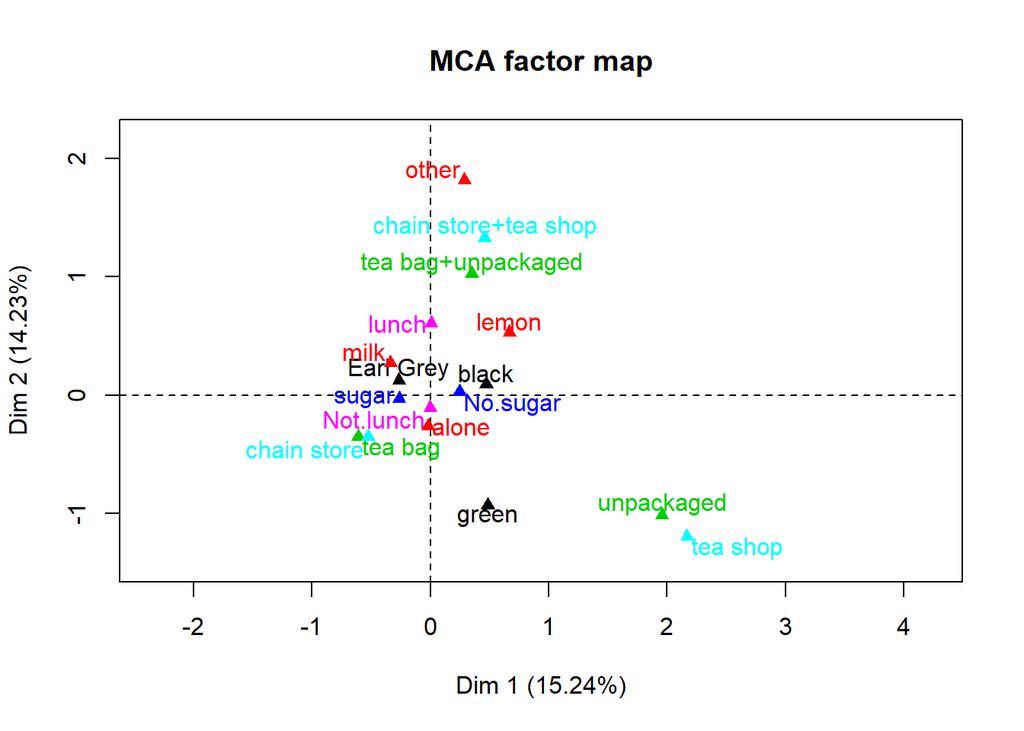

```r
plot(mca, invisible=c("ind"),habillage = "quali")
```

The cumulative percentage of variance explained by the first two MCA dimensions is 29.5%. We can see variable categories that are closer to each other in the mca biplot (each variable is colored differently, i.e variable categories of a variable are colored the same). For example,variable category earl grey appears closer with variable categories sugar and milk, indicating how it is drunk by the individuals in the tea data.